# Reproducible Research: Peer Assessment 1

FVB

29 de diciembre de 2017

## Loading and preprocessing the data

The first thing that we do is, in order to be reproducible, coding the process of downloading the data and also the required packages for the script to work.

Note: In order to make the reading clear, information or warning messages are turned off.

```r
if (!("dplyr" %in% installed.packages()[,1])) {install.packages("dplyr")}
if (!("ggplot2" %in% installed.packages()[,1])) {install.packages("ggplot2")}
library(dplyr)
library(ggplot2)


download.file(url = "https://d396qusza40orc.cloudfront.net/repdata%2Fdata%2Factivity.zip",
              destfile = "./monitordata.zip")
unzip(zipfile = "monitordata.zip")
monitordata<-read.csv(file = "./activity.csv",col.names = c("steps","date","interval"))

monitordata$interval[1:15]
```

```
##  [1]   0   5  10  15  20  25  30  35  40  45  50  55 100 105 110
```

You can check that the way the interval its registered is unnatural since every hour it restarts a 0-55 count and adds 100 to its value. We correct this so we get intervals that look more natural: the accumulation of consecutive increases of 5 min, from 0 (=00:00) to 1435 (23:55).

In order to do this what we do its an arithmetical operation in which we substract 40 from the number it has for every multiple of 100 that its value contains.

```r
monitordata$interval <-monitordata$interval-(40*trunc(monitordata$interval/100))

monitordata$interval[1:15]
```

```
##  [1]  0  5 10 15 20 25 30 35 40 45 50 55 60 65 70
```

With this the data set is already ready for working with it.

## What is mean total number of steps taken per day?

For answering this we group our data by day and we summarise our results in a table where we calculate the total number of steps done, mean and median for each day. In this step we remove NA values for our calculations.

```r
monitdat.day<-group_by(.data = monitordata,date)
steps.summ.d<-summarise(monitdat.day, steps.tot=sum(steps,na.rm = TRUE),
   steps.mean=mean(steps,na.rm = TRUE),steps.median= median(steps,na.rm = TRUE))
print(steps.summ.d)
```

```
## # A tibble: 61 x 4
##          date steps.tot steps.mean steps.median
##        <fctr>     <int>      <dbl>        <dbl>
##  1 2012-10-01         0        NaN           NA
##  2 2012-10-02       126    0.43750            0
##  3 2012-10-03     11352   39.41667            0
##  4 2012-10-04     12116   42.06944            0
##  5 2012-10-05     13294   46.15972            0
##  6 2012-10-06     15420   53.54167            0
##  7 2012-10-07     11015   38.24653            0
##  8 2012-10-08         0        NaN           NA
##  9 2012-10-09     12811   44.48264            0
## 10 2012-10-10      9900   34.37500            0
## # ... with 51 more rows
```

Then we get a histogram of the total number of steps done each day.

To make our histogram have a more easy to understand format, we choose the breaks for separate the different columns of our histogram to correspond approximately with the equivalent of a km (around 1300 steps according to a Google search).

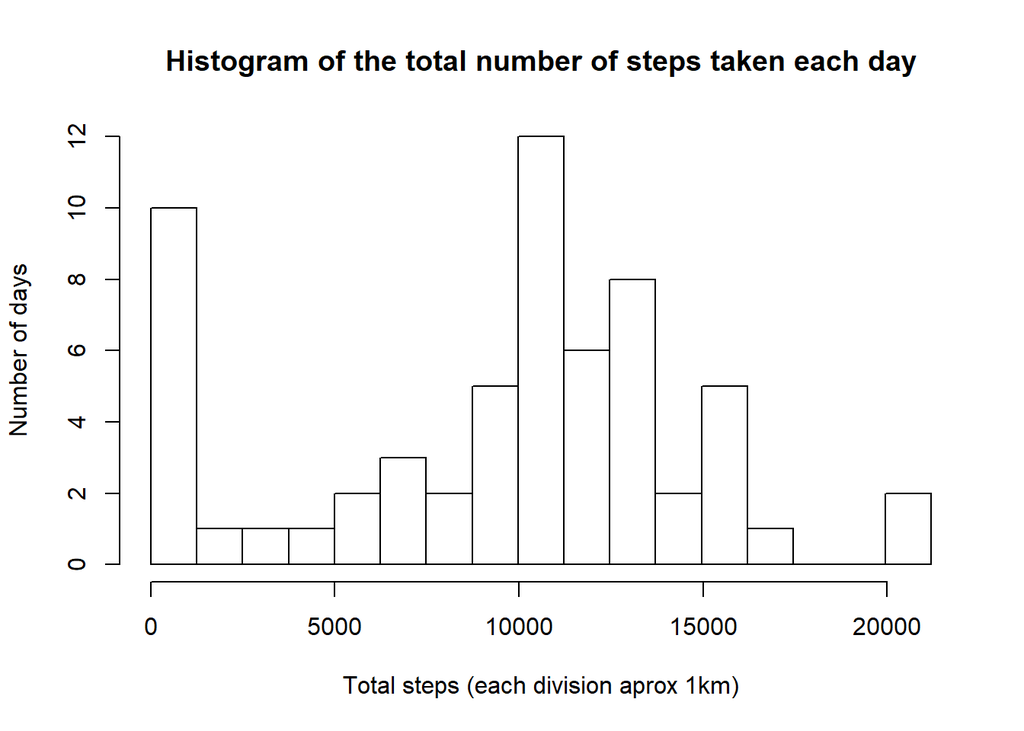

```r
hist(steps.summ.d$steps.tot,breaks = seq(0,21194,21194/17),
  main = "Histogram of the total number of steps taken each day",
  ylab = "Number of days",xlab = "Total steps (each division aprox 1km)")
```

## What is the average daily activity pattern?

For this we group our data by their interval values and we make an activity time line, averaged across all days.

```r
monitdat.inter<-group_by(.data = monitordata,interval)
steps.summ.inter<-summarise(monitdat.inter, steps.tot=sum(steps,na.rm = TRUE),
   steps.mean=mean(steps,na.rm = TRUE),steps.median= median(steps,na.rm = TRUE))
print(steps.summ.inter)
```

```
## # A tibble: 288 x 4
##    interval steps.tot steps.mean steps.median
##       <dbl>     <int>      <dbl>        <int>
##  1        0        91  1.7169811            0
##  2        5        18  0.3396226            0
##  3       10         7  0.1320755            0
##  4       15         8  0.1509434            0
##  5       20         4  0.0754717            0
##  6       25       111  2.0943396            0
##  7       30        28  0.5283019            0
##  8       35        46  0.8679245            0
##  9       40         0  0.0000000            0
## 10       45        78  1.4716981            0
## # ... with 278 more rows
```

Again to give a much easily understandable approach to our data we plot our data against the time in hours and not in minutes.

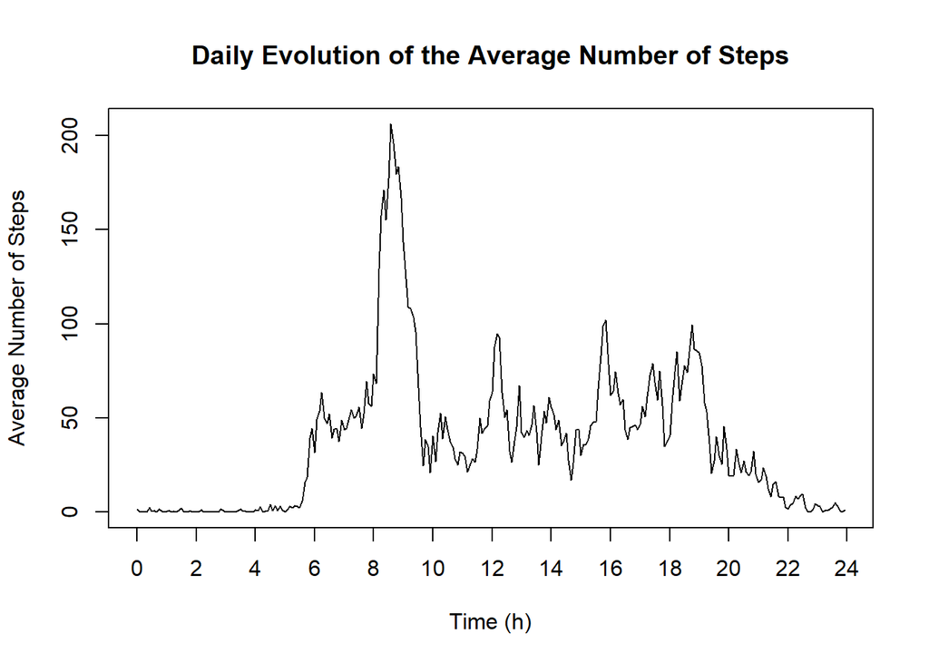

```r
plot(x = steps.summ.inter$interval/60, y=steps.summ.inter$steps.mean,type = "l",
    xlab = "Time (h)", ylab = "Average Number of Steps",
    main = "Daily Evolution of the Average Number of Steps",xaxp=c(0,24,12))
```

```r
max.inter.val<-steps.summ.inter$interval[steps.summ.inter$steps.mean==max(steps.summ.inter$steps.mean)]
```

We calculate the maximal interval according to the averaged number of steps value across all days :515 minutes / 8.5833333 hours.

## Imputing missing values

```r
total.na<-sum(is.na(monitordata$steps))
print(total.na)
```

```
## [1] 2304
```

```r
na.pos<-which(is.na(monitordata$steps))
unique(as.Date(monitordata$date)[na.pos])
```

```
## [1] "2012-10-01" "2012-10-08" "2012-11-01" "2012-11-04" "2012-11-09"
## [6] "2012-11-10" "2012-11-14" "2012-11-30"
```

```r
na.pos.s<-which(steps.summ.d$steps.tot==0)
steps.summ.d$date[na.pos.s]
```

```
## [1] 2012-10-01 2012-10-08 2012-11-01 2012-11-04 2012-11-09 2012-11-10
## [7] 2012-11-14 2012-11-30
## 61 Levels: 2012-10-01 2012-10-02 2012-10-03 2012-10-04 ... 2012-11-30
```

We have seem so far that many missing values (NA) were present in our data (2304), when we check if their presence follows some pattern we could see that they correspond to eight specific whole days and so we can not use the daily average as a way to substitute them instead we will use the interval average.

Once we got the positions we substitute the NA by their corresponding average interval values

```r
monitdat.rev<-monitordata

for( i in na.pos){
        monitdat.rev$steps[i]<-steps.summ.inter$steps.mean[steps.summ.inter$interval == monitordata$interval[i]]
}
```

With the new values we follow an identical process to address the previous first question, and we compare the two histograms to see their differences.

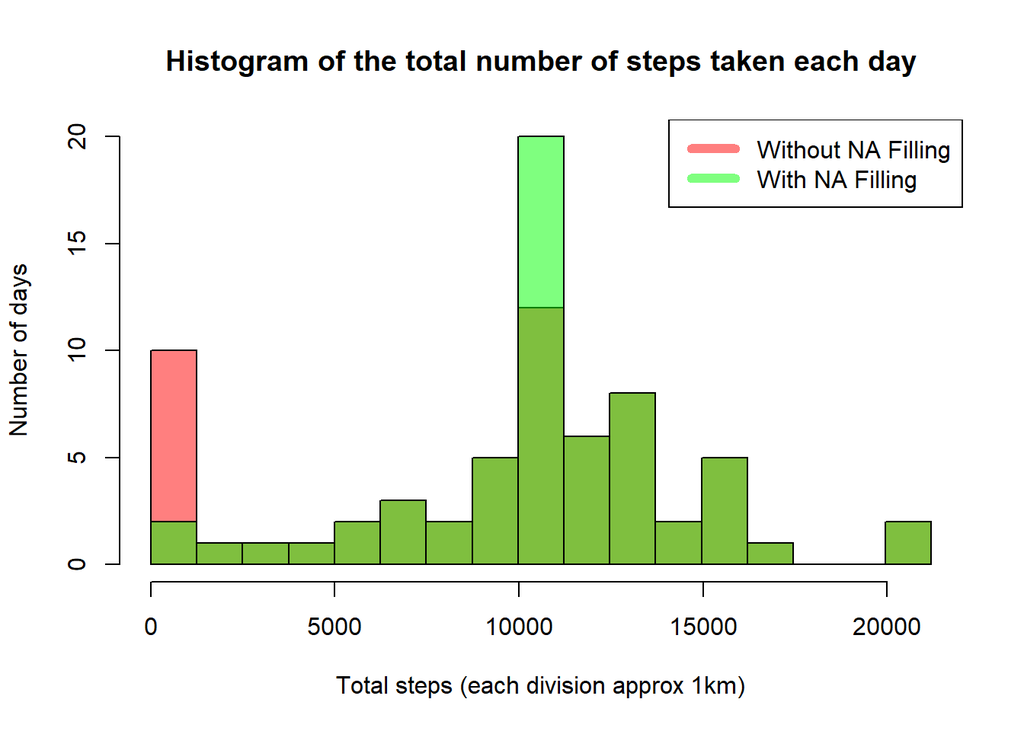

```r
monitdat.day.rev<-group_by(.data = monitdat.rev,date)
steps.summ.d.rev<-summarise(monitdat.day.rev, steps.tot=sum(steps,na.rm = TRUE),
   steps.mean=mean(steps,na.rm = TRUE),steps.median= median(steps,na.rm = TRUE))

hist(steps.summ.d$steps.tot,breaks = seq(0,21194,21194/17),
  main = "Histogram of the total number of steps taken each day",
  ylab = "Number of days",xlab = "Total steps (each division approx 1km)",
  ylim = c(0,20), col=rgb(1,0,0,0.5))

hist(steps.summ.d.rev$steps.tot,breaks = seq(0,21194,21194/17),
     col=rgb(0,1,0,0.5),add=TRUE)

legend("topright", legend = c("Without NA Filling","With NA Filling"),
       lty= c(1,1),lwd = 6, col = c(rgb(1,0,0,0.5),rgb(0,1,0,0.5)))
```

As long as all the days didn’t have measurements and they have undergone the same modifications, the changes in their averages and medians are the same:

```r
print(steps.summ.d[na.pos.s,])
```

```
## # A tibble: 8 x 4
##         date steps.tot steps.mean steps.median
##       <fctr>     <int>      <dbl>        <dbl>
## 1 2012-10-01         0        NaN           NA
## 2 2012-10-08         0        NaN           NA
## 3 2012-11-01         0        NaN           NA
## 4 2012-11-04         0        NaN           NA
## 5 2012-11-09         0        NaN           NA
## 6 2012-11-10         0        NaN           NA
## 7 2012-11-14         0        NaN           NA
## 8 2012-11-30         0        NaN           NA
```

```r
print(steps.summ.d.rev[na.pos.s,])
```

```
## # A tibble: 8 x 4
##         date steps.tot steps.mean steps.median
##       <fctr>     <dbl>      <dbl>        <dbl>
## 1 2012-10-01  10766.19    37.3826     34.11321
## 2 2012-10-08  10766.19    37.3826     34.11321
## 3 2012-11-01  10766.19    37.3826     34.11321
## 4 2012-11-04  10766.19    37.3826     34.11321
## 5 2012-11-09  10766.19    37.3826     34.11321
## 6 2012-11-10  10766.19    37.3826     34.11321
## 7 2012-11-14  10766.19    37.3826     34.11321
## 8 2012-11-30  10766.19    37.3826     34.11321
```

Even if this tendency was already partially perceived by the unaffected days (dark green): our correction displaces its center from a broarder range of 10k-12.5k steps.

## Are there differences in activity patterns between weekdays and weekends?

For review the second question again we decide to group the new values according to another parameter: if their day belongs to the weekday or the weekend. For this we add a new factor column to our data and then group our data by the kind of day they belong to and their intervals. After that we calculate their new means and medians, averaged now only among their kind of day.

Note: We set the language of the system to english to make our code work properly

```r
Sys.setlocale("LC_TIME", locale = "C")
```

```
## [1] "C"
```

```r
monitdat.rev$day.kind <- factor(ifelse(weekdays(as.Date(monitdat.rev$date))==
  "Saturday"|weekdays(as.Date(monitordata$date))=="Sunday","weekend","weekday"))

monitdat.inter<-group_by(.data = monitordata,interval)
monitdat.rev.kind.inter<-group_by(.data = monitdat.rev,day.kind,interval)

steps.summ.inter.rev<-summarise(monitdat.rev.kind.inter,
steps.tot=sum(steps,na.rm = TRUE),steps.mean=mean(steps,na.rm = TRUE),
steps.median= median(steps,na.rm = TRUE))
head(steps.summ.inter.rev)
```

```
## # A tibble: 6 x 5
## # Groups:   day.kind [1]
##   day.kind interval  steps.tot steps.mean steps.median
##     <fctr>    <dbl>      <dbl>      <dbl>        <dbl>
## 1  weekday        0 101.301887 2.25115304            0
## 2  weekday        5  20.037736 0.44528302            0
## 3  weekday       10   7.792453 0.17316562            0
## 4  weekday       15   8.905660 0.19790356            0
## 5  weekday       20   4.452830 0.09895178            0
## 6  weekday       25  71.566038 1.59035639            0
```

We plot the daily evolution for the two kind of days.

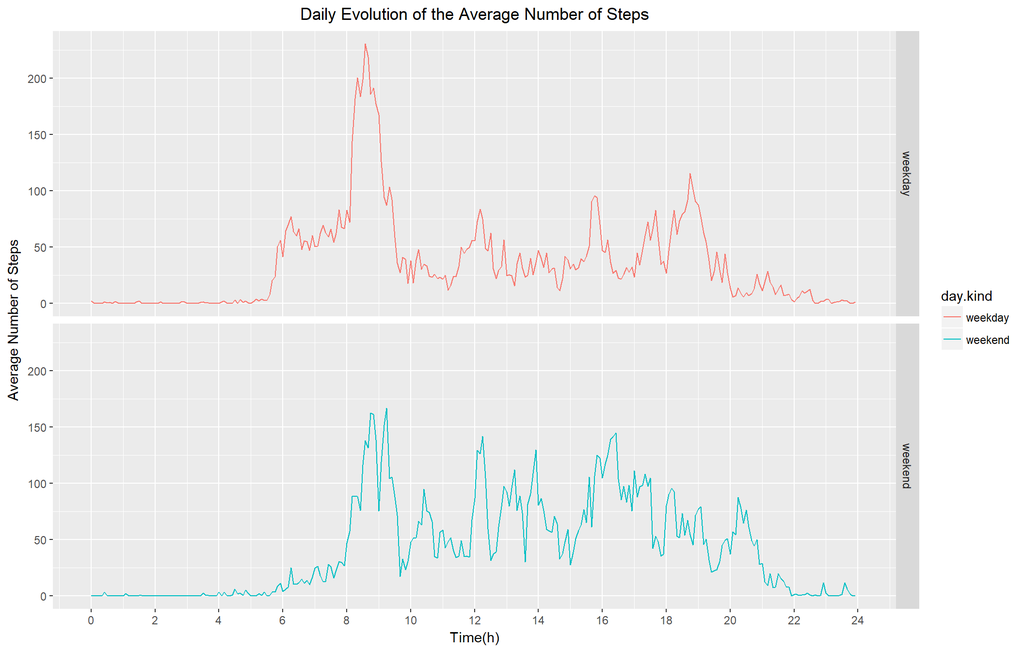

```r
ggplot(data = steps.summ.inter.rev,aes(x=interval/60,y=steps.mean, colour=day.kind))+
geom_line()+facet_grid(day.kind~.)+
labs(title="Daily Evolution of the Average Number of Steps",x="Time(h)",y="Average Number of Steps")+
theme(plot.title = element_text(hjust = 0.5))+
scale_x_continuous(breaks = seq.int(0,24,2),limits = c(0,24))
```

We can see several differences:

- On weekdays the movement starts and finishes, on average, earlier than on weekends (starts around 6/8 and finishes around 20/21). Surely this is related mainly to working schedules that are absent on weekends.
- On average the amount of steps done afetr the commuting to work range (9:30 a.m on) is bigger on weekends: this is probably due to the absence of space restriction given by an office work, and so probably people go shopping, having lunch outside, hiking, etc, in general activities that require movement.
- Finally in both cases theres a similar increase of movement between 8-9:30 a.m. It’s not clear the reason behind this.

We might be suspicious if their differences only come due to our method for substitution, but if we check the days with NA presence we can see they are present in both types of day.

```r
na.days <- list (unique(as.Date(monitdat.rev$date)[na.pos]),unique(weekdays(as.Date(monitdat.rev$date))[na.pos]))
print(na.days)
```

```
## [[1]]
## [1] "2012-10-01" "2012-10-08" "2012-11-01" "2012-11-04" "2012-11-09"
## [6] "2012-11-10" "2012-11-14" "2012-11-30"
##
## [[2]]
## [1] "Monday"    "Thursday"  "Sunday"    "Friday"    "Saturday"  "Wednesday"
```